# Exercises on Bootstrap

Nonparametric statistics ay 2021/2022

2021/10/22

#Problem 1

The local administration of Torgnon, a small municipality in Aosta Valley, has given you the task to assess the probability of a flood coming from the small river that crosses the village. To do so, they given you data about the maximum water level (in metres) of the past 50 years. The major is only willing to accept a 5% probability of flood. so your wall should be high at least as the 95th percentile of the maximums distribution.

1. Assess the statistical quality of the sample 95th percentile, and compute a 95 percent confidence interval for it
2. After some study, you’ve discovered that the maximum value of level of water is usually distributed as a lognormal: How can you use this information? Has your estimate of the sample 95th percentile improved?

#Solution

Let’s read and plot the data, so we understand a bit the situation

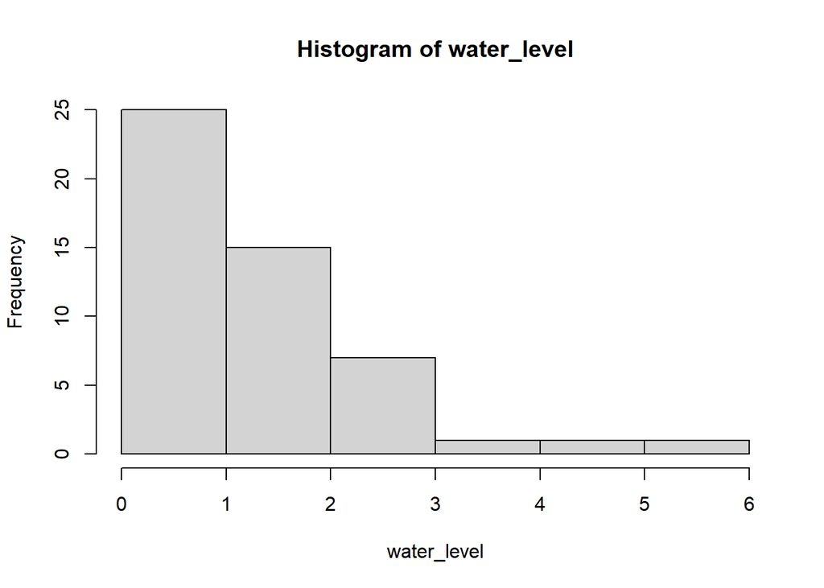

```r
load('water_level_data/water_level.rda')

hist(water_level)
```

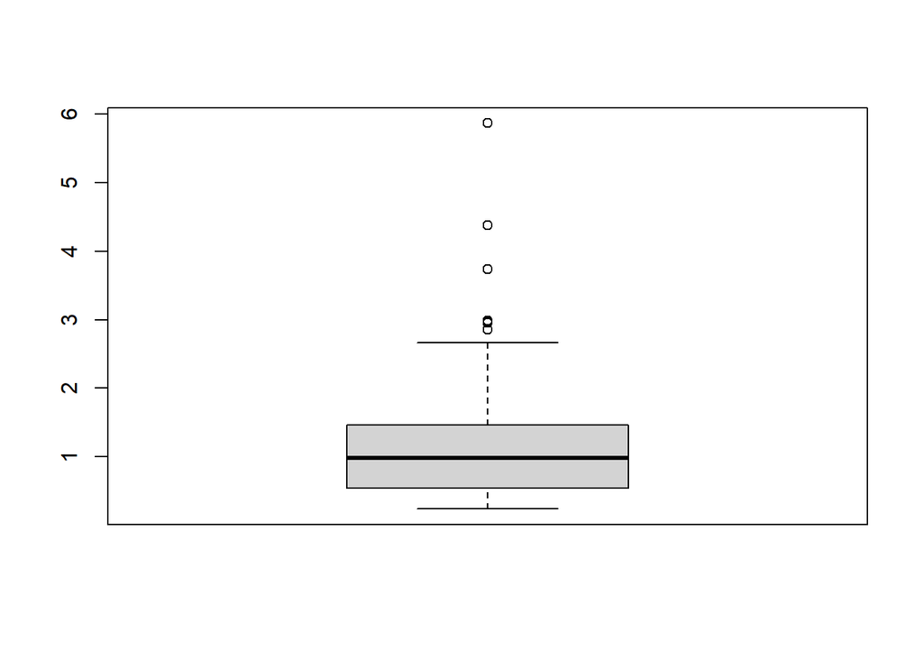

```r
boxplot(water_level)
```

To assess the quality and compute a confidence interval, the way to go is by bootstrapping, so

```r
B <- 10000
water.obs=water_level

q95.obs=quantile(water.obs,0.95)
q95.boot = numeric(B)
for(b in 1:B)
{
  water.b <- sample(water.obs, replace = T)
  q95.boot[b] = quantile(water.b,0.95)
}
```

Let’s plot the ecdf

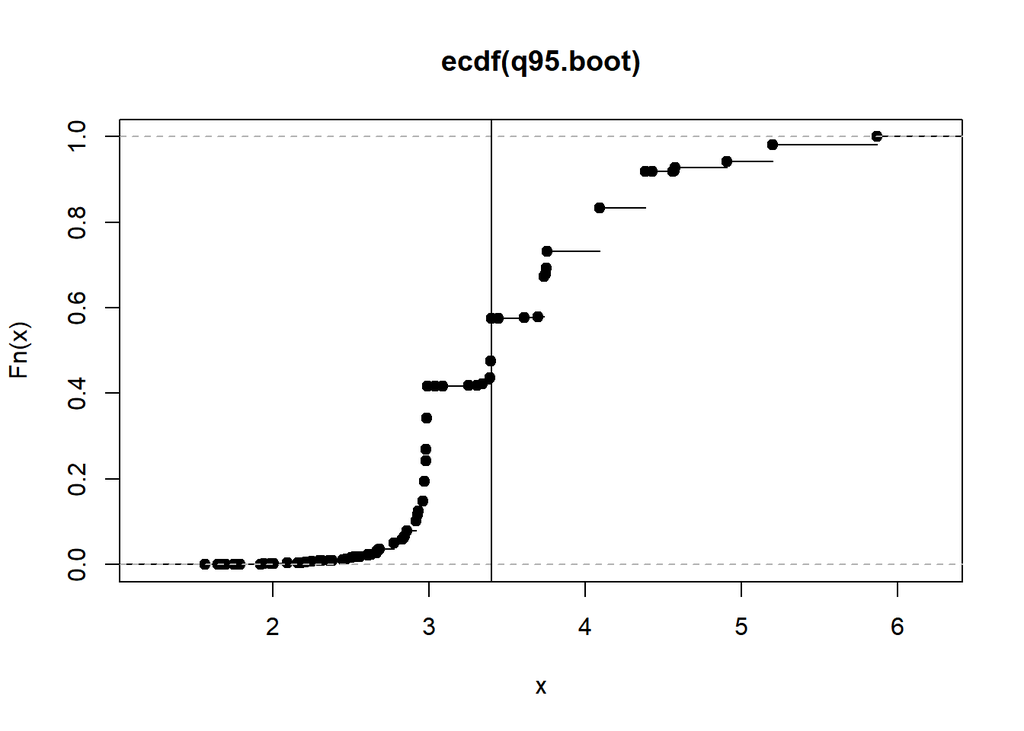

```r
plot(ecdf(q95.boot))
abline(v = q95.obs)
```

To assess the quality of the estimation what you need to provide are the bootstrap variance, the bias, and with those you can easily estimate the RMSE

```r
var=var(q95.boot)
bias=mean(q95.boot)-q95.obs
names(bias)=''
RMSE=sqrt(var+bias^2)
var
```

```
## [1] 0.5243664
```

```r
bias
```

```
##
## 0.1535846
```

```r
RMSE
```

```
##
## 0.7402395
```

For a CI,let’s use classic reverse percentile intervals.

```r
alpha <- 0.05

right.quantile <- quantile(q95.boot, 1 - alpha/2)
left.quantile  <- quantile(q95.boot, alpha/2)

CI.RP <- c(q95.obs - (right.quantile - q95.obs), q95.obs, q95.obs - (left.quantile - q95.obs))
names(CI.RP)=c('lwr','lvl','upr')
```

to solve the second part, we understand that we can use a parametric bootstrap. We need to fit a lognormal to our data, and then run bootstrap simulations out of it… but how to estimate the parameters of a lognormal? How can I do it? It’s easy peasy…

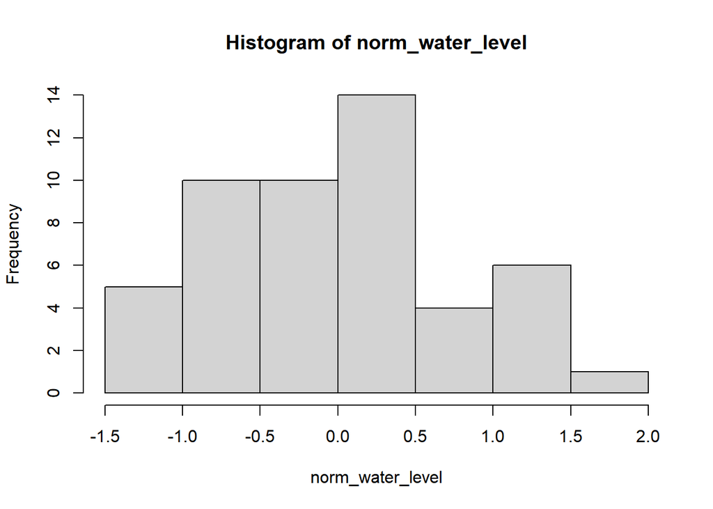

```r
norm_water_level=log(water_level)
hist(norm_water_level)
```

```r
shapiro.test(norm_water_level)
```

```
##
##  Shapiro-Wilk normality test
##
## data:  norm_water_level
## W = 0.97866, p-value = 0.4969
```

The log of my data is normal… as the they come from a lognormal distribution. So how can I generate from such distirbution?

```r
mean=mean(norm_water_level)
sd=sqrt(var(norm_water_level))
n=length(norm_water_level)

q95.boot.p = numeric(B)

for(b in 1:B)
{
  water.b <- exp(rnorm(n,mean,sd))
  q95.boot.p[b] = quantile(water.b,0.95)
}
```

Let’s plot the ecdf

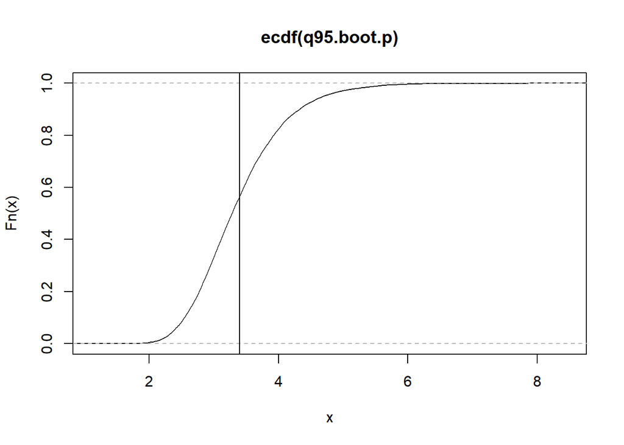

```r
plot(ecdf(q95.boot.p))
abline(v = q95.obs)
```

and, let’s compute the performance of parametric bootstrap, and then compare them to the nonparametric case

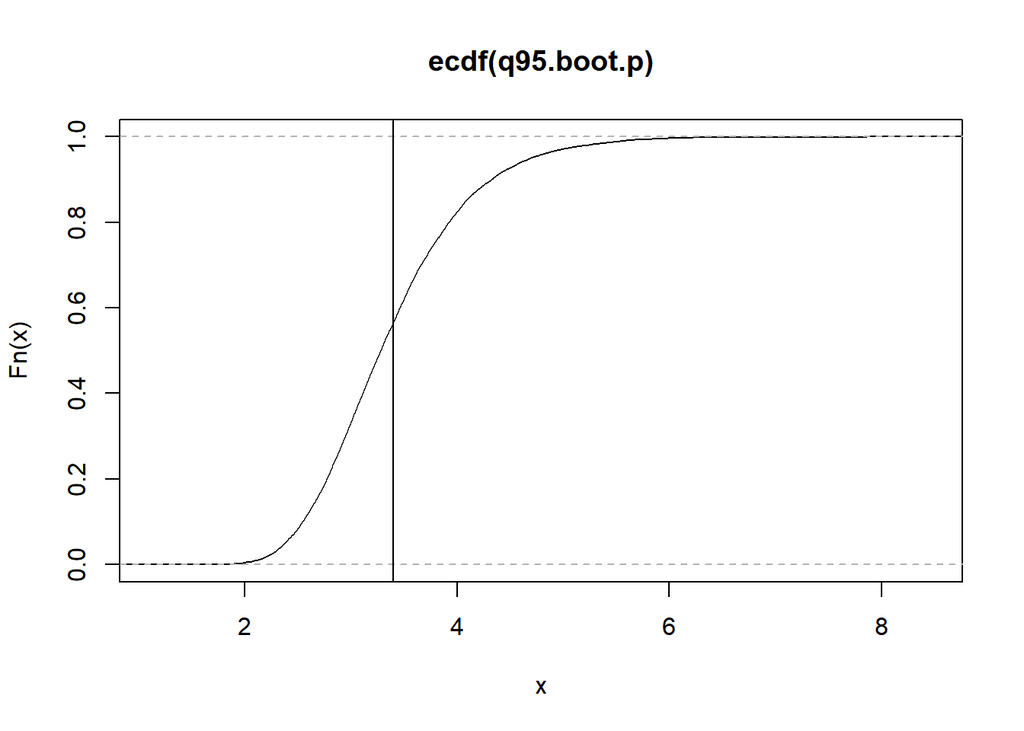

```r
plot(ecdf(q95.boot.p))
abline(v = q95.obs)
```

```r
var.p=var(q95.boot.p)
bias.p=mean(q95.boot.p)-q95.obs
RMSE.p=sqrt(var.p+bias.p^2)

var=var(q95.boot)
bias=mean(q95.boot)-q95.obs
RMSE=sqrt(var+bias^2)

data.frame("Non Parametric"=c(var,bias,RMSE),"Parametric"=c(var.p,bias.p,RMSE.p))
```

| Non.Parametric | Parametric |
| --- | --- |
| 0.5243664 | 0.52329292 |
| 0.1535846 | -0.02291529 |
| 0.7402395 | 0.72375274 |

We can of course compute a confidence interval with the classical reverse quantile strategy

```r
alpha <- 0.05

right.quantile <- quantile(q95.boot.p, 1 - alpha/2)
left.quantile  <- quantile(q95.boot.p, alpha/2)

CI.RP.p <- c(q95.obs - (right.quantile - q95.obs), q95.obs, q95.obs - (left.quantile - q95.obs))
CI.RP.p
```

```
##      95%      95%      95%
## 1.723050 3.399583 4.541082
```

#Problem 2 The chief coach of the Aosta ski club has tasked you to select who, among its three top-class athletes in alpine skiing, can successfully compete also in ski-cross races, which have been recently “promoted” to an alpine discipline from its former “freestyle” status. One of the key areas in ski-cross is the moment when the athlete “jumps” in the track: this, differently from alpine skiing, happens after the blow of a whistle. For this reason, fast reaction times can make the difference between losing and winning. You’re so given the data about 100 “start” trials for the three athletes, stored in “parallel_gate.rda” The chief coach is asking if: 1. Are there any differences among the athletes? (see if you can use a parametric approach, if not, use a permutational one) 2. From a preliminary visual analysis, athlete 3 seems the best: how can you assess this, knowing what you discovered in 1.? 3. The coach is also asking you an idea of the “consistency” of athlete 3 out of the gate: provide him with a confidence interval for the mean of his reaction time.

#Solution

Let’s load the data, and plot it, after having converted the athlete variable to a factor.

```r
#load the data
load('parallel_gate_data/parallel_gate.rda')
head(chrono)
```

|  | reaction_time | athlete |
| --- | --- | --- |
| 1 | 2.3109997 | 1 |
| 2 | 2.2880683 | 1 |
| 3 | 1.6137042 | 1 |
| 4 | 0.8816244 | 1 |
| 5 | 1.9886475 | 1 |
| 6 | 1.5348088 | 1 |

```r
#convert athlete to factor
chrono$athlete=factor(chrono$athlete)
summary(chrono)
```

```
##  reaction_time    athlete
##  Min.   :0.1691   1:100
##  1st Qu.:0.9751   2:100
##  Median :1.5398   3:100
##  Mean   :1.5237
##  3rd Qu.:2.0319
##  Max.   :2.9766
```

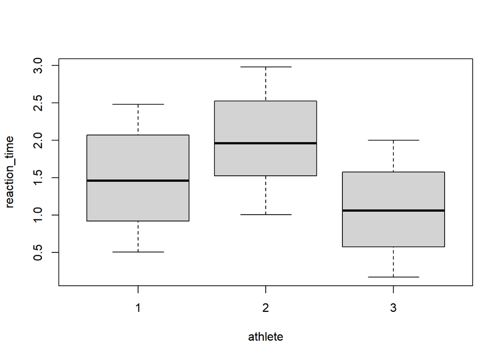

```r
attach(chrono)
boxplot(reaction_time ~ athlete)
```

Let’s assess if I can use classical ANOVA

```r
model_norm=aov(reaction_time ~ athlete)
summary(model_norm)
```

```
##              Df Sum Sq Mean Sq F value Pr(>F)
## athlete       2   45.9   22.95   67.47 <2e-16 ***
## Residuals   297  101.0    0.34
## ---
## Signif. codes:  0 '***' 0.001 '**' 0.01 '*' 0.05 '.' 0.1 ' ' 1
```

```r
shapiro.test(model_norm$residuals)
```

```
##
##  Shapiro-Wilk normality test
##
## data:  model_norm$residuals
## W = 0.94391, p-value = 2.888e-09
```

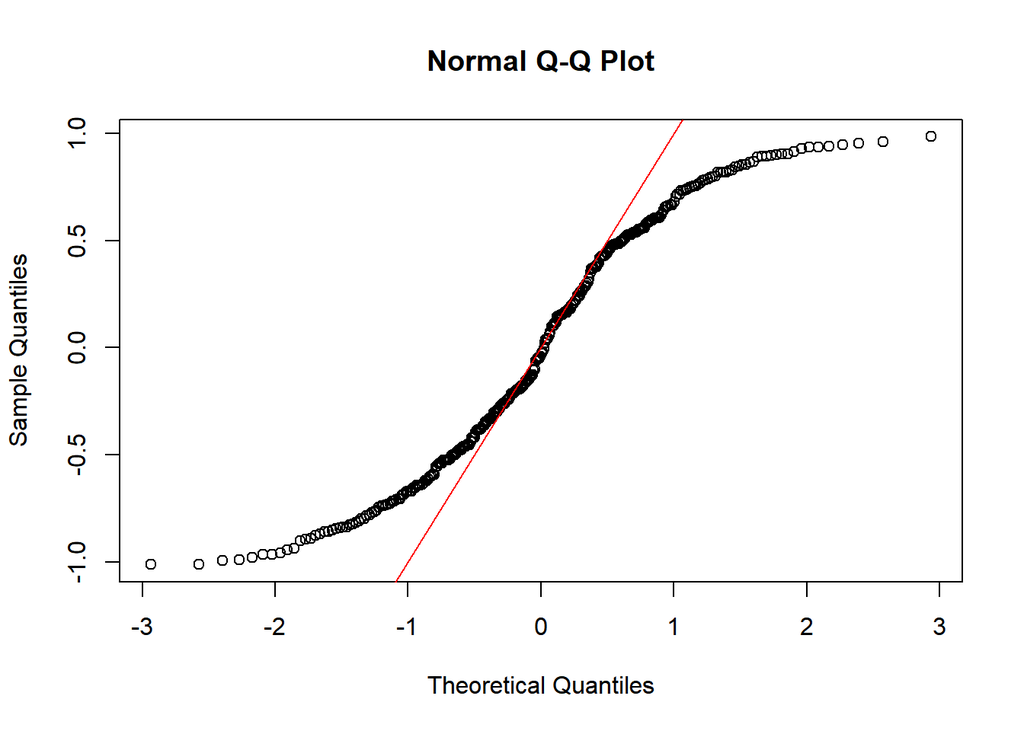

```r
qqnorm(model_norm$residuals)
abline(a=0,b=1,col='red')
```

normality is not verified, let’s go permutational

```r
T0 <- summary(model_norm)[[1]][1,4]

T0
```

```
## [1] 67.46514
```

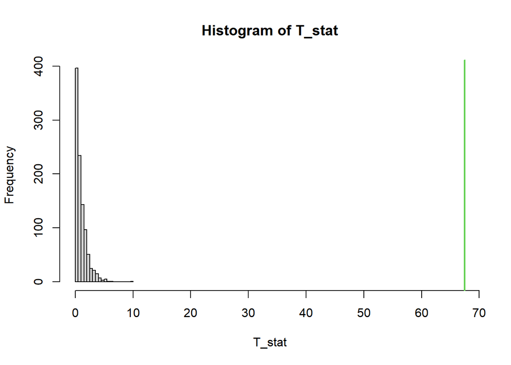

```r
B <- 1000 # Number of permutations
T_stat <- numeric(B)
n <- nrow(chrono)

  for(perm in 1:B){
    # Permutation:
    permutation <- sample(1:n)
    reaction_perm <- reaction_time[permutation]
    model_perm <- aov(reaction_perm ~ athlete)

    # Test statistic:
    T_stat[perm] <- summary(model_perm)[[1]][1,4]
  }


hist(T_stat,xlim=range(c(T_stat,T0)),breaks=30)
abline(v=T0,col=3,lwd=2)
```

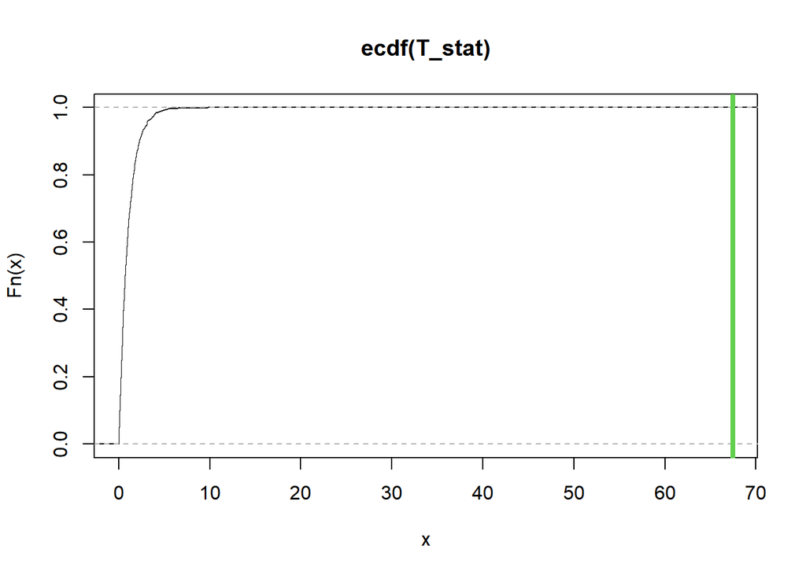

```r
plot(ecdf(T_stat),xlim=range(c(T_stat,T0)))
abline(v=T0,col=3,lwd=4)
```

```r
# p-value
p_val <- sum(T_stat>=T0)/B
p_val
```

```
## [1] 0
```

P-Value is zero, so you have a statistically significant difference between athlethes. To answer the next point, you need to perform a proper post hoc test. Tet’s go with two permutational t-tests, using as a reference level 3 (the best candidate) to be the fastest out of the gate. We start with 3 vs 1

```r
pooled1=chrono[athlete!=2,]
n1=nrow(pooled1)
ath_3=pooled1$athlete==3
T0=abs(mean(pooled1$reaction_time[ath_3])-mean(pooled1$reaction_time[!ath_3]))




T_stat=numeric(B)
for(perm in 1:B){
  # permutation:
  permutation <- sample(1:n1)
  time_perm <- pooled1$reaction_time[permutation]
  ref_perm <- time_perm[ath_3]
  other_perm <- time_perm[!ath_3]
  # test statistic:
  T_stat[perm] <- abs(mean(other_perm) - mean(ref_perm))
}

p_val <- sum(T_stat>=T0)/B
p_val
```

```
## [1] 0
```

Now 3 vs 2

```r
pooled2=chrono[athlete!=1,]
n2=nrow(pooled2)
ath_3=pooled2$athlete==3
T0=abs(mean(pooled2$reaction_time[ath_3])-mean(pooled2$reaction_time[!ath_3]))




T_stat=numeric(B)
for(perm in 1:B){
  # permutation:
  permutation <- sample(1:n1)
  time_perm <- pooled1$reaction_time[permutation]
  ref_perm <- time_perm[ath_3]
  other_perm <- time_perm[!ath_3]
  # test statistic:
  T_stat[perm] <- abs(mean(other_perm) - mean(ref_perm))
}

p_val <- sum(T_stat>=T0)/B
p_val
```

```
## [1] 0
```

To solve the third point, you can either choose a permutational or a bootstrap approach, let’s start with the permutational one

```r
uni_t_perm=function(data,mu0,B=1000){

  data_trans=data-mu0
  T0=abs(mean(data_trans))
  T_perm=numeric(B)
  n=length(data)

  for(perm in 1:B){

    refl <- rbinom(n, 1, 0.5)*2 - 1
    T_perm[perm]=abs(mean(data_trans*refl))

  }
  return(sum(T_perm>=T0)/B)
}

library(pbapply)
library(parallel)


grid=seq(0,2,by=0.001)

cl=makeCluster(2)
ath_3=reaction_time[athlete==3]


clusterExport(cl,varlist=list("ath_3","uni_t_perm"))

mean(ath_3)
```

```
## [1] 1.0602
```

```r
perm_wrapper=function(grid_point){uni_t_perm(ath_3,grid_point)}
pval_function=pbsapply(grid,perm_wrapper,cl=cl)
pval_function
```

[output not shown]

[output cut: 152 more lines]

```r
plot(grid,pval_function,type='l')

range(grid[pval_function>0.05])
```

```
## [1] 0.947 1.167
```

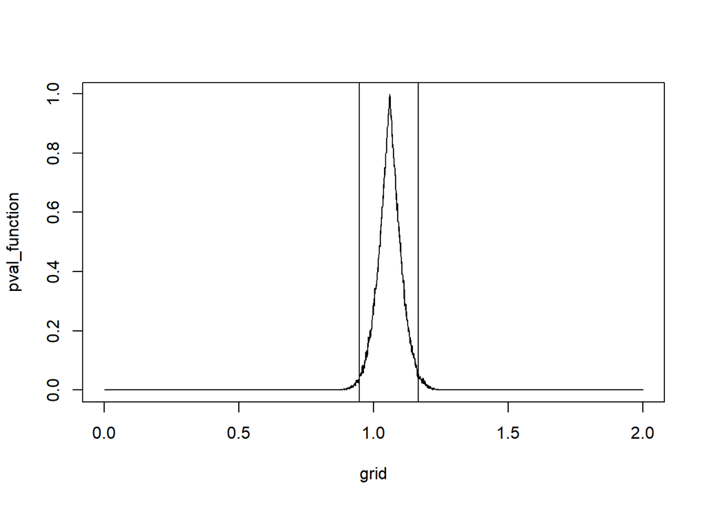

```r
abline(v=range(grid[pval_function>0.05]))
```

Here is the (simpler…) bootstrap solution

```r
#the part could've been equivalently solved by using a bootstrap approach:


T0=mean(ath_3)
B=1000
T.boot=numeric(B)

for(b in 1:B)
{
  x.b <- sample(ath_3, replace = T)
  T.boot[b] <- mean(x.b)
}

# RP intervals

alpha <- 0.05

right.quantile <- quantile(T.boot, 1 - alpha/2)
left.quantile  <- quantile(T.boot, alpha/2)

T0
```

```
## [1] 1.0602
```

```r
right.quantile - T0
```

```
##     97.5%
## 0.1112583
```

```r
left.quantile  - T0
```

```
##       2.5%
## -0.1086562
```

```r
CI.RP <- c(T0 - (right.quantile - T0), T0 - (left.quantile - T0))
CI.RP
```

```
##     97.5%      2.5%
## 0.9489416 1.1688561
```

```r
range(grid[pval_function>0.05])
```

```
## [1] 0.947 1.167
```